# *Pay for Luck* no Mercado Brasileiro: Efeitos da Pandemia de Covid-19 e o Papel da Governança

Exame de Qualificação  
Mestrado Profissional em Administração  
IFMG - Campus Formiga

**Igor Neves Nunes**

Mestrando

Prof. Dr. Washington S. da Silva

Orientador

Prof. Dr. Lélis Pedro de Andrade

Coorientador

1 de agosto de 2025

## Sumário

**Tópicos**

- Introdução
- Revisão da Literatura
  - Fundamentação Teórica
  - Evidências Internacionais
  - Evidências Nacionais
  - Lacuna de Pesquisa e Justificativa
- Objetivos
  - Objetivo Geral
  - Objetivos Específicos
- Metodologia
- Resultados Esperados
- Cronograma
- Referências

## Introdução

**Motivação**

# Revisão da Literatura

# Fundamentação Teórica

## Teoria da Agência

**Jensen e Meckling (1976)**

## Poder Gerencial

**Bebchuk e Fried (2003)**

## *Pay for Luck*

**Bertrand e Mullainathan (2001)**

## Medidas Relativas de Desempenho

**Bertrand e Mullainathan (2001), Garvey e Milbourn (2006), Jackson, Plumlee e Rountree (2018)**

# Evidências Internacionais

## Estudos sobre Remuneração Executiva e Covid-19

**Ye, Chen e Kelly (2023)**

## Estudos sobre Remuneração Executiva e Covid-19

**Danysh-Hashemi (2023)**

## O Papel da Governança

**Ding *et al.* (2021)**

# Evidências Nacionais

## Borges *et al.* (2024)

**Descrição**

## Brandão (2024)

**Descrição**

## Lacuna de Pesquisa e Justificativa

**Lacunas Identificadas**

# Objetivos

## Objetivo Geral

**Descrição**

Analisar como o desempenho relativo das empresas influencia a remuneração dos executivos brasileiros, considerando a moderação da pandemia de Covid-19 e de mecanismos de governança corporativa sobre essa relação.

## Objetivos Específico 1

**Artigo Empírico**

## Objetivos Específico 2

**Pacote da Linguagem R**

# Metodologia

## Análise Descritiva

**Procedimentos**

## Variáveis

Tabela 1: Variáveis Planejadas para o Estudo

| Variável | Descrição |
| --- | --- |
| y (Variável dependente) | Logaritmo da remuneração fixa, remuneração variável e remuneração total da diretoria executiva. |
| perf | Retorno acionário (mercado, setor, idiossincrático) e retorno contábil (mercado, setor, idiossincrático). |
| Covid | Variável dummy que assume 1 para o período da pandemia e 0 caso contrário. |
| Cons | Variáveis relativas ao conselho de administração: tamanho, independência e diversidade. |
| Contr | Dummy que assume 1 caso a empresa tenha controlador e 0 caso contrário. |
| Seg | Segmento de listagem da empresa, conforme classificação da B3. |
| Tam | Tamanho da empresa, representado pelo logaritmo dos ativos totais. |

## Modelagem Econométrica

**Endogeneidade**

## Modelagem Econométrica

**Modelos Dinâmicos**

- Planeja-se estimar três **modelos dinâmicos** para os dados em painel, usando o **Método Generalizado dos Momentos (GMM)** para estimá-los.
- Uma especificação geral está representada na Eq. 1:

$$y_{it} = \beta_0 + \beta_1 y_{it-1} + \beta_2 perf_{it} + \beta_3 Covid_t + \beta_4 (perf_{it} \times Covid_t) \\
+ \beta_5 Cons_{it} + \beta_6 (perf_{it} \times Cons_{it}) + \beta_7 Contr_{it} + \beta_8 (perf_{it} \times Contr_{it}) \\
+ \beta_9 Seg_{it} + \beta_{10} Tam_{it} + \alpha_i + \gamma_t + \epsilon_{it}
\qquad(1)$$
Sendo:

- $\alpha_i$ e $\gamma_t$: efeitos fixos de empresa e tempo, e;
- $\epsilon_{it}$ o termo de erro do modelo

## Decomposição das Medidas de Desempenho

**Componente Acionário**

Para o componente acionário, o retorno das ações será decomposto conforme a equação:

$$V_1 = \beta r_m + \delta L + \gamma X + \epsilon \tag{2}$$

onde $V_1$ representa o retorno bruto, $\beta$ é a sensibilidade ao retorno de mercado $r_m$, $\delta$ captura a sensibilidade a choques específicos $L$, $\gamma$ $X$ representa controles adicionais.

## Decomposição das Medidas de Desempenho

**Componente Contábil**

Para o componente contábil, será calculado o Retorno sobre Ativos Operacionais Líquidos (RNOA):

$$RNOA_{i,q} = \frac{OIADPQ_{i,q}}{NOA_{i,q}} \tag{3}$$

A decomposição do RNOA seguirá o procedimento de Jackson, Plumlee e Rountree (2018), isolando os componentes de mercado, setorial e específico da firma através das seguintes etapas:

1. Cálculo do RNOA setorial excluindo a empresa $i$:

$$RNOA^I_{j,q} = \frac{\sum (OIADPQ_{j,q}) - OIADPQ_{i,j,q}}{\sum (NOA_{j,q}) - NOA_{i,j,q}} \tag{4}$$

2. Cálculo do RNOA de mercado:

$$RNOA^M_{q} = \frac{\sum (OIADPQ_{q}) - OIADPQ_{i,j,q}}{\sum (NOA_{q}) - NOA_{i,j,q}} \tag{5}$$

3. Regressão para isolar o efeito setorial:

$$RNOA^I_{j,q} = \beta_0 + \beta_1 RNOA^M_q + \epsilon \tag{6}$$

4. Estimação da sensibilidade individual:

$$RNOA_{i,j,q} = \beta'_0 + \beta'_1\hat{\epsilon_{j,q}} + \beta'_2RNOA^M_q + \epsilon',
\tag{7}$$

5. Decomposição final:

$$MktRNOA_{i,j,q} = \hat{\beta'}_2 \times RNOA^M_q \tag{8}$$

$$IndRNOA_{i,j,q} = \hat{\beta'_1} \times RNOA^I_{j,q} \tag{9}$$

$$IdiosRNOA_{i,j,q} = RNOA_{i,j,q} - MktRNOA_{i,j,q} - IndRNOA_{i,j,q} \tag{10}$$

## Processamento e Análise dos Dados

**Ferramentas e Estratégias**

- Os procedimentos de importação, preparação, estimação de modelos e análise serão realizadas utilizando a linguagem R (R Core Team, 2025), empregando, entre outros, pacotes para modelos de dados em painel tais como pdynmc (Fritsch, Pua e Schnurbus, 2021) e/ou plm (Croissant e Millo, 2008).
- As estratégias econométricas adotadas seguirão as recomendações metodológicas consolidadas na literatura sobre dados em painel, conforme apresentado em (Baltagi, 2021; Wooldridge, 2010).

## Dados

**Descrição**

# Resultados Esperados

## Resultados Empíricos Esperados

**Comportamento da Remuneração Executiva e Relação com o Desempenho**

## Resultados Empíricos Esperados

**Resultados metodológicos**

## Produtos Bibliográficos e Técnicos

**Producões**

- Artigo Empírico
- Pacote da Linguagem R

## Impactos Esperados

**Impactos**

## Cronograma

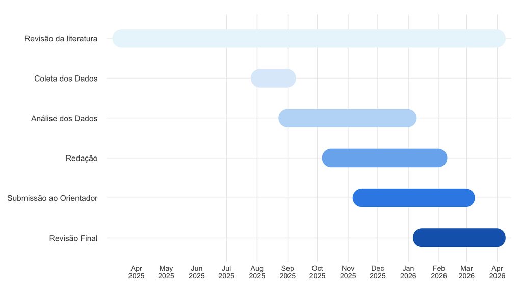

Figura 1: Etapas planejadas para execução do projeto.

## Referências

BALTAGI, B. H. **[Econometric Analysis of Panel Data](https://doi.org/10.1007/978-3-030-53953-5)**. 6. ed. Cham, Switzerland: Springer, 2021.

BEBCHUK, L. A.; FRIED, J. M. [Executive compensation as an agency problem](https://doi.org/10.1257/089533003769204362). **Journal of Economic Perspectives**, v. 17, n. 3, p. 71–92, 2003.

BERTRAND, M.; MULLAINATHAN, S. [Are CEOs Rewarded for Luck? The Ones Without Principals Are](https://doi.org/10.1162/00335530152466269). **The Quarterly Journal of Economics**, v. 116, n. 3, p. 901–932, 2001.

BORGES, A. F. P. *et al.* Sensibilidade da remuneração executiva à performance financeira das companhias brasileiras listadas na B3: uma análise antes e durante a pandemia de COVID-19. **ResearchGate**, 2024.

BRANDÃO, I. DE F. [Governança corporativa em tempos de pandemia: análise das empresas brasileiras](https://doi.org/10.18046/j.estger.2024.173.6797). **Estudios Gerenciales**, v. 40, n. 173, p. 460–476, 2024.

CROISSANT, Y.; MILLO, G. [Panel Data Econometrics in R: The plm Package](https://doi.org/10.18637/jss.v027.i02). **Journal of Statistical Software**, v. 27, n. 2, p. 1–43, 2008.

DANYSH-HASHEMI, S. [The Interactive Effect of Covid-19 Pandemic, Political Cost, and Executive Compensation on Earnings Management](https://digitalcommons.newhaven.edu/americanbusinessreview/vol26/iss2/7/). **American Business Review**, v. 26, n. 2, p. 97–115, 2023.

DING, W. *et al.* [Corporate Immunity to the COVID-19 Pandemic](https://doi.org/10.1016/j.jfineco.2021.03.005). **Journal of Financial Economics**, v. 141, n. 2, p. 802–830, 2021.

FRITSCH, M.; PUA, A.; SCHNURBUS, J. [pdynmc: A Package for Estimating Linear Dynamic Panel Data Models Based on Nonlinear Moment Conditions](https://doi.org/10.32614/RJ-2021-035). **The R Journal**, v. 13, n. 1, p. 218–231, 2021.

GARVEY, G. T.; MILBOURN, T. T. [Asymmetric benchmarking in compensation: Executives are rewarded for good luck but not penalized for bad](https://doi.org/10.1016/j.jfineco.2004.01.006). **Journal of Financial Economics**, v. 82, n. 1, p. 197–225, 2006.

JACKSON, A. B.; PLUMLEE, M. A.; ROUNTREE, B. R. [Decomposing the market, industry, and firm components of profitability: implications for forecasts of profitability](https://doi.org/10.1007/s11142-018-9446-2). **Review of Accounting Studies**, v. 23, n. 3, p. 1071–1095, 2018.

JENSEN, M. C.; MECKLING, W. H. Theory of the firm: Managerial behavior, agency costs and ownership structure. **Journal of Financial Economics**, v. 3, n. 4, p. 305–360, 1976.

R CORE TEAM. **[R: A Language and Environment for Statistical Computing](https://www.R-project.org/)**. Vienna, Austria: R Foundation for Statistical Computing, 2025.

WOOLDRIDGE, J. M. **Econometric Analysis of Cross Section and Panel Data**. 2. ed. Cambridge, MA: MIT Press, 2010.

YE, R.; CHEN, Y.; KELLY, K. A. [The effects of firm performance on CEO compensation and CEO pay ratio before and during COVID-19](https://doi.org/10.1016/j.rie.2023.07.002). **Research in Economics**, v. 77, p. 453–458, dez. 2023.